# Counting Ssd1 motifs in Schizosaccharomyces pombe, approximate 5’UTRs with fixed length upstream of CDSs

Edward Wallace

14/02/2021

# Summary

We are looking for occurences of the major part of the Ssd1-binding motif, `CNYTCNYT`, in *Schizosaccharomyces pombe*.

Here we downloaded the 1000nt of genomic sequence upstream of translation start codons from [fungidb](https://fungidb.org/).

The major finding is that this motif is comparatively rare in *S. pombe* upstream sequences, and genes with the motif are enriched in cell wall proteins and membrane proteins. This is what we expected.

# Load approximate 1000nt UTRs

```r
# define fasta filename
Sp_up1000_file <- paste(here::here(),
                        "motif_conservation",
                        "data",
                        "Spombe_972h-_ATG_upstream_1000nt.fasta",
                        sep= "/")

# load fasta file as DNA string set
Sp_up1000_DSS <- readDNAStringSet(Sp_up1000_file)
# remove truncated sequences, which we don't need.
Sp_up1000_DSS <- Sp_up1000_DSS[width(Sp_up1000_DSS) == 1000]

# assign just the ORF id to the name, but keep all the info.
Sp_namesinfo <-
    tibble(everything = names(Sp_up1000_DSS)) %>%
    tidyr::separate(everything,into = c("id","strain","info","seqtype","seq","length"), sep = " \\| ") %>%
    dplyr::select(id, info,seq)

names(Sp_up1000_DSS) <- Sp_namesinfo$id

# print the DNA string set to check it came out ok
Sp_up1000_DSS
```

```
## DNAStringSet object of length 6992:
##        width seq                                            names
##    [1]  1000 ATAATCACAAAGGGATTTCCAC...CTCTCGATTCAACATGGGTGA SPBCPT2R1.10
##    [2]  1000 TAGCATTTCGACGGTTGGACAA...ATGGTAGCTTAAGTTGGCAAA SPBC21B10.13c
##    [3]  1000 GCAAGGTACTTCATTTTGACGA...CGTGTGGTATAAAAACGTATC SPBP8B7.05c
##    [4]  1000 TGTAAGCACGAGCATATGCAAC...AAGAGAACAGCACTGGTCAAA SPAC644.15
##    [5]  1000 ACTCAATGTTTCAACCAAGTAC...CCTTTTTATTATCCTTTTTAT SPAC20G8.02
##    ...   ... ...
## [6988]  1000 AAGGCAACGATAGGACCCTTGT...CCACCGGCCACTTCGTACAAG SPCC569.08c
## [6989]  1000 TTTTTGCTCTTGCTGAACTTGA...TAATGATACGTTAAATCACCA SPNCRNA.1600
## [6990]  1000 CCAGTTAATTTTTTACGACACA...TGTCCTTTCCTAACCTTTGCA SPBC1778.01c
## [6991]  1000 TAGCCAGCTCTTAGCAGCTAAA...CCAACTCCCAACTCAATTCCC SPAC24C9.16c
## [6992]  1000 CATATTAAGGGATGGGAAAGGA...AACGAAAGCGGAAGTACGTAA SPNCRNA.293
```

# Count occurences of Ssd1 motif CNYTCNYT

We use functions from Biostrings (bioconductor) to find motif instances. This was inspired by [a blogpost from kasper daniel hansen](https://kasperdanielhansen.github.io/genbioconductor/html/Biostrings_Matching.html).

We use `fixed = "subject"` to allow ambiguous characters in the pattern `CNYTCNYT`, but not in the sequence being searched.

We put all the relevant counts into a tibble for easier post-processing.

```r
CNYTCNYT_count_df <- tibble(id = Sp_namesinfo$id,
                            info = Sp_namesinfo$info,
                            count_up1000 = vcountPattern(pattern = DNAString("CNYTCNYT"),
                                 subject = Sp_up1000_DSS,
                                 fixed = "subject"),
                            count_up200 = vcountPattern(pattern = DNAString("CNYTCNYT"),
                                 subject = subseq(Sp_up1000_DSS,start = 801L, end = 1000L),
                                 fixed = "subject"),
                            count_up100 = vcountPattern(pattern = DNAString("CNYTCNYT"),
                                 subject = subseq(Sp_up1000_DSS,start = 901L, end = 1000L),
                                 fixed = "subject")
)

summary(CNYTCNYT_count_df)
```

```
##       id                info            count_up1000     count_up200
##  Length:6992        Length:6992        Min.   : 0.000   Min.   : 0.0000
##  Class :character   Class :character   1st Qu.: 0.000   1st Qu.: 0.0000
##  Mode  :character   Mode  :character   Median : 1.000   Median : 0.0000
##                                        Mean   : 1.457   Mean   : 0.3445
##                                        3rd Qu.: 2.000   3rd Qu.: 1.0000
##                                        Max.   :16.000   Max.   :11.0000
##   count_up100
##  Min.   :0.0000
##  1st Qu.:0.0000
##  Median :0.0000
##  Mean   :0.1884
##  3rd Qu.:0.0000
##  Max.   :9.0000
```

## Which genes have highest counts?

```r
arrange(CNYTCNYT_count_df,desc(count_up100)) %>%
    head(n = 20) %>%
    knitr::kable()
```

| id | info | count_up1000 | count_up200 | count_up100 |
| --- | --- | --- | --- | --- |
| SPBC29B5.02c | OPT oligopeptide transmembrane transporter family Isp4 | 12 | 11 | 9 |
| SPAC1F7.07c | iron permease Fip1 | 8 | 8 | 8 |
| SPAPB24D3.07c | Schizosaccharomyces pombe specific protein | 5 | 5 | 5 |
| SPBC19G7.05c | 1,3-beta-glucan synthase catalytic subunit Bgs1 | 13 | 6 | 4 |
| SPAC23H3.11c | glucosidase (predicted) | 8 | 7 | 4 |
| SPAC1F7.08 | iron transport multicopper oxidase Fio1 | 6 | 5 | 4 |
| SPAC13G6.10c | cell wall protein Asl1, predicted O-glucosyl hydrolase | 4 | 4 | 3 |
| SPBC106.02c | sulfiredoxin | 5 | 3 | 3 |
| SPAC6G10.12c | transcription factor Ace2 | 3 | 3 | 3 |
| SPAC12B10.11 | glucan glucosidase Exg2, unknown specificity | 5 | 4 | 3 |
| SPBC28E12.03 | Rho-type GTPase activating protein Rga4 | 5 | 3 | 3 |
| SPAC1002.13c | cell wall protein Psu1, beta-glucosidase (predicted) | 5 | 4 | 3 |
| SPAC23A1.02c | phosphoprotein phosphatase (predicted) | 6 | 3 | 3 |
| SPAC11D3.05 | MFS family transmembrane transporter Mfs2 (predicted) | 3 | 3 | 3 |
| SPAC19A8.01c | guanyl-nucleotide exchange factor Sec73 (predicted) | 7 | 3 | 3 |
| SPBC146.07 | U2AF large subunit (U2AF-59) | 4 | 3 | 3 |
| SPBC83.13 | mitochondrial tricarboxylic acid transmembrane transporter (predicted) | 4 | 3 | 3 |
| SPAC2F3.09 | 5-aminolevulinate synthase Hem1 | 6 | 3 | 3 |
| SPCC757.12 | alpha-amylase homolog (predicted) | 6 | 4 | 3 |
| SPBC713.12 | squalene monooxygenase Erg1 (predicted) | 9 | 3 | 3 |

## 1000nt upstream

Results from all 1000nt upstream.

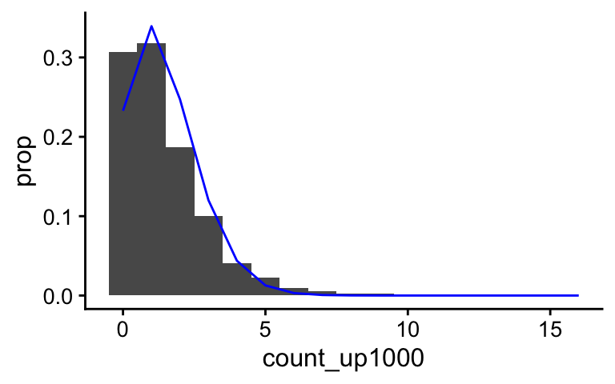

```r
CNYT_up1000_reducedmean <- CNYTCNYT_count_df %>%
    pull(count_up1000) %>%
    mean()

CNYT_up1000_reducedvar <- CNYTCNYT_count_df %>%
    pull(count_up1000) %>%
    var()

ggplot(data = CNYTCNYT_count_df, aes(x = count_up1000)) +
    geom_bar(width = 1, aes(y = ..prop..), stat = "count", group = 1) +
    geom_line(data = tibble(),
              aes(x = 0:20, y = dpois(0:20,lambda=CNYT_up1000_reducedmean)),
              colour = "blue") +
    scale_x_continuous(limits = c(-0.5,16), oob = scales::squish)
```

This count is overdispersed relative to a Poisson distribution, with mean 1.4572368, variance 2.6378506.

## 100nt upstream

Results filtered to only the 100nt closest to the start codon.

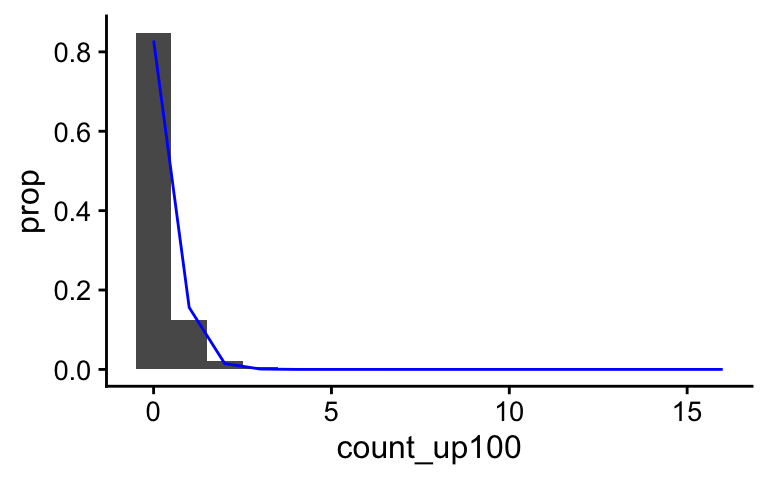

```r
CNYT_up100_reducedmean <- CNYTCNYT_count_df %>%
    pull(count_up100) %>%
    mean()

CNYT_up100_reducedvar <- CNYTCNYT_count_df %>%
    pull(count_up100) %>%
    var()

ggplot(data = CNYTCNYT_count_df, aes(x = count_up100)) +
    geom_bar(width = 1, aes(y = ..prop..), stat = "count", group = 1) +
    geom_line(data = tibble(),
              aes(x = 0:20, y = dpois(0:20,lambda=CNYT_up100_reducedmean)),
              colour = "blue") +
    scale_x_continuous(limits = c(-0.5,16), oob = scales::squish)
```

This count is also overdispersed relative to a Poisson distribution, with mean 0.1883581, variance 0.2550325.

# Write list of genes for GO search, based on counts 100nt upstream

```r
id_file_CNYTCNYT1_up100 <- paste(here::here(),
                                 "motif_conservation",
                                 "results",
                                 "Sp_id_list_CNYTCNYT1_up100.txt", sep = "/")

CNYTCNYT_count_df %>%
    filter(count_up100 >= 1) %>%
    pull(id) %>%
    write_lines(file = id_file_CNYTCNYT1_up100)

id_file_CNYTCNYT2_up100 <- paste(here::here(),
                        "motif_conservation",
                        "results",
                        "Sp_id_list_CNYTCNYT2_up100.txt",
                        sep = "/")

CNYTCNYT_count_df %>%
    filter(count_up100 >= 2) %>%
    pull(id) %>%
    write_lines(file = id_file_CNYTCNYT2_up100)
```

Next, I did a GO term finder search of these genelists on the [princeton generic GO term finder](https://go.princeton.edu/GOTermFinder/), using terms from [pombase](https://www.pombase.org/).

Cite PMID: 15297299

> “GO::TermFinder--open source software for accessing Gene Ontology information and finding significantly enriched Gene Ontology terms associated with a list of genes.” Boyle et al, Bioninformatics (2004)

That search found significantly enriched GO terms including cell wall, cell periphery, and intrinsic component of membrane, (component) in genes with at least 2x CNYTCNYT motifs in the 100nt upstream, file `Sp_id_list_CNYTCNYT2_up100.txt`. Results are saved in the file `Sp_goFinderResult_component_pombase_id_list_CNYTCNYT2_up100.txt`.

Some of the genes identified here containing at least 2 `CNYTCNYT` motifs are also identified as differentially expressed in the absence of Sts5 by [Nunez et al](https://elifesciences.org/articles/14216). There’s lots of cell wall-modifying enzymes such as:

- cell wall beta-glucosidase Psu1
- cell wall and ascospore endo-1,3-beta-glucanase Eng2
- primary septum and spore wall linear 1,3-beta-glucan synthase catalytic subunit Bgs1

Another protein reported as differentially expressed in absence of Sts5 is SPBP23A10.11c, predicted circularly permuted 1,3-beta-glucanase. The *S. cerevisiae* homolog Tos1 is bound by Ssd1. *S. pombe* SPBP23A10.11c has a long 5’UTR, 3 CNYTCNYT motifs in the 200nt upstream of ATG, and 14 such motifs in the 1000nt upstream.

Another protein in our list with 5x CNYTCNYT sites, SPAPB24D3.07c “S. pombe specific protein”, is annotated with the phenotype “incomplete cell wall disassembly at cell fusion site” in the deletion mutant by [Dudin et al 2007](https://www.pombase.org/reference/PMID:28410370).